# arctic-tern-migration-final

```python
import matplotlib.pyplot as plt
import matplotlib.image as mpimg
```

### Arctic Tern Mirgration: A Global Untertaking

[Adult Arctic Tern](https://www.allaboutbirds.org/guide/assets/photo/308404421-1280px.jpg)

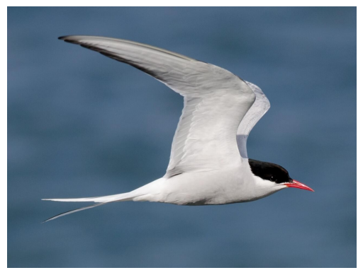

```python
img = mpimg.imread('/workspaces/species-distribution-coding-challenge-ZimmZone/notebooks/Adult Artic Terns.jpg')
imgplot = plt.imshow(img)

# Remove axes, ticks, and labels
plt.axis('off')

# Show the image without plotlines
plt.show()
```

## Arctic Terns

Arctic terns have the most impressive migration of any species on earth. Their yearly migration stretches from pole to pole, at a distance of anywhere from 44,000 to 59,000 kilometers. Terns are distinguishable by their red beaks and feet, their deeply forked tail, and their black skull cap.

Arctic Terns are small birds, weiging in at an averages of 3.5 oz. They are light enough to use the ocean breezes to go long distance without having to expend energy flapping. When not nesting on shore these birds spend most of their lives at sea and are thus able to live and even sleep entirely in the air.

If you wish to see an Arctic Tern, your best opportunity will be during their extensive coastal migrations. Otherwise, you can catch them nesting in their circumpolar breeding range, which includes the sub-Arctic regions of Europe, Asia, and North America. But be careful, Arctic Terns are very agressive to perceived trespassers.

## Data Description

Data was drawn from the Global Biodiversity Information Facility (GBIF), which is an international network and data infrastructure funded by the world's governments. GBIF gathers data from many sources, including museaum specimens all the way to DNA parcodes and smartphone images. Drawing these data sources together using data standards, including Darwin Core, this information is provided open access using machine-readable Creative Commons license designations.

Data on Arctic Tern (Sterna paradisaea) migration for the year 2023 was used.

Ecoregion data was drawn from RESOLVE and One Earth . All ecoregions were included as the Arctic Tern migration path is global.

## Methods

Data was normalized by area size of the observation area (i.e. ecoregion) in relation to the number of observed occurences per month. It is understood that there will be fewer observations in the colder months and when the terns are in areas of less-dense human habitation (e.g. offshore or in the sub-arctic).

## Arctic Tern Migration Path by Month

The interactive map below demonstrates a few significant points:

- The global nature of the Arctic Tern migration
- The largely coastal nature of the migration
- The existance of some intercontinental sightings
- Terns are much more likely to be spotted during the breeding season when they are on land (May to July)

[figure not shown]